# HT1

Joshua Chicoj

2023-01-27

## Hoja de Trabajo 1: Análisis exploratorio

### Ejercicio 1

A continuación se presenta un resumen de los datos de la base de datos *Movies*

```r
summary(movies)
```

```
##        id             budget             genres            homePage
##  Min.   :     5   Min.   :        0   Length:10000       Length:10000
##  1st Qu.: 12286   1st Qu.:        0   Class :character   Class :character
##  Median :152558   Median :   500000   Mode  :character   Mode  :character
##  Mean   :249877   Mean   : 18551632
##  3rd Qu.:452022   3rd Qu.: 20000000
##  Max.   :922260   Max.   :380000000
##  productionCompany  productionCompanyCountry productionCountry
##  Length:10000       Length:10000             Length:10000
##  Class :character   Class :character         Class :character
##  Mode  :character   Mode  :character         Mode  :character
##
##
##
##     revenue             runtime        video           director
##  Min.   :0.000e+00   Min.   :  0.0   Mode :logical   Length:10000
##  1st Qu.:0.000e+00   1st Qu.: 90.0   FALSE:9430      Class :character
##  Median :1.631e+05   Median :100.0   TRUE :84        Mode  :character
##  Mean   :5.674e+07   Mean   :100.3   NA's :486
##  3rd Qu.:4.480e+07   3rd Qu.:113.0
##  Max.   :2.847e+09   Max.   :750.0
##     actors          actorsPopularity   actorsCharacter    originalTitle
##  Length:10000       Length:10000       Length:10000       Length:10000
##  Class :character   Class :character   Class :character   Class :character
##  Mode  :character   Mode  :character   Mode  :character   Mode  :character
##
##
##
##     title           originalLanguage     popularity        releaseDate
##  Length:10000       Length:10000       Min.   :    4.258   Length:10000
##  Class :character   Class :character   1st Qu.:   14.578   Class :character
##  Mode  :character   Mode  :character   Median :   21.906   Mode  :character
##                                        Mean   :   51.394
##                                        3rd Qu.:   40.654
##                                        Max.   :11474.647
##     voteAvg         voteCount      genresAmount    productionCoAmount
##  Min.   : 1.300   Min.   :    1   Min.   : 0.000   Min.   : 0.000
##  1st Qu.: 5.900   1st Qu.:  120   1st Qu.: 2.000   1st Qu.: 2.000
##  Median : 6.500   Median :  415   Median : 3.000   Median : 3.000
##  Mean   : 6.483   Mean   : 1342   Mean   : 2.596   Mean   : 3.171
##  3rd Qu.: 7.200   3rd Qu.: 1316   3rd Qu.: 3.000   3rd Qu.: 4.000
##  Max.   :10.000   Max.   :30788   Max.   :16.000   Max.   :89.000
##  productionCountriesAmount  actorsAmount    castWomenAmount
##  Min.   :  0.000           Min.   :     0   Length:10000
##  1st Qu.:  1.000           1st Qu.:    13   Class :character
##  Median :  1.000           Median :    21   Mode  :character
##  Mean   :  1.751           Mean   :  2148
##  3rd Qu.:  2.000           3rd Qu.:    36
##  Max.   :155.000           Max.   :919590
##  castMenAmount
##  Length:10000
##  Class :character
##  Mode  :character
##
##
##
```

### Ejercicio 2

A continuación se presentan las variables, según su clasificación:

- Variables Cuantitativas:
  - Discretas:
    - runtime
    - voteAvg
    - voteCount
    - genresAmount
    - productionCoAmoun
    - productionCountriesAmount
    - actorsAmount
    - castWomenAmount
    - castMenAmount
  - Continuas:
    - budget
    - revenue
- Variables Cualitativas:
  - Nominal:
    - genres
    - homePage
    - productionCompany
    - productionCompanyCountry
    - productionCountry
    - video
    - director
    - actors
    - actorsCharacter
    - originalTitle
    - title
    - originalLanguage
  - Ordinal:
    - actorsPopularity
    - popularity
    - releaseDate

### Ejercicio 4

#### 4.1 ¿Cuáles son las 10 películas que contaron con más presupuesto?

```r
moreBudget <- movies[order(movies$budget,decreasing = TRUE), ]
moreBudget[1:10,15]
```

```
##  [1] "Pirates of the Caribbean: On Stranger Tides"
##  [2] "Avengers: Age of Ultron"
##  [3] "Avengers: Endgame"
##  [4] "Pirates of the Caribbean: At World's End"
##  [5] "Justice League"
##  [6] "Avengers: Infinity War"
##  [7] "Superman Returns"
##  [8] "Tangled"
##  [9] "The Lion King"
## [10] "Spider-Man 3"
```

#### 4.2 ¿Cuáles son las 10 películas que más ingresos tuvieron?

```r
moreRevenue <- movies[order(movies$revenue,decreasing = TRUE), ]
moreRevenue[1:10,15]
```

```
##  [1] "Avatar"                       "Avengers: Endgame"
##  [3] "Titanic"                      "Star Wars: The Force Awakens"
##  [5] "Avengers: Infinity War"       "Jurassic World"
##  [7] "The Lion King"                "Spider-Man: No Way Home"
##  [9] "The Avengers"                 "Furious 7"
```

#### 4.3 ¿Cuál es la película que más votos tuvo?

```r
moreVotes <- movies[order(movies$voteCount,decreasing = TRUE), ]
moreVotes[1:10,15]
```

```
##  [1] "Inception"               "Interstellar"
##  [3] "The Dark Knight"         "The Avengers"
##  [5] "Deadpool"                "Avatar"
##  [7] "Guardians of the Galaxy" "Avengers: Infinity War"
##  [9] "Fight Club"              "Pulp Fiction"
```

#### 4.4 ¿Cuál es la peor película de acuerdo a los votos de todos los usuarios?

```r
lessVote <- movies[order(movies$voteAvg,decreasing = FALSE), ]
lessVote[1,15]
```

```
## [1] "劇場版 抱かれたい男1位に脅されています。~スペイン編~"
```

#### 4.10 ¿Quiénes son los directores que hicieron las 20 películas mejor calificadas?

```r
datos <- read.csv("movies.csv")
puntaje<- datos$voteAvg
directores <- datos$director
ordenPuntaje<- order(puntaje,decreasing = TRUE)
mejores <- list()
for (i in 1:20){
  actual <- directores[ordenPuntaje[i]]
  if (actual==""){
    mejores[i] <- "desconocido"
  }else{
    mejores[i]<- actual
  }
}
mejores
```

```
## [[1]]
## [1] "Thomas Coven"
##
## [[2]]
## [1] "Víctor Barba|Juan Olivares"
##
## [[3]]
## [1] "Rebecca Sugar"
##
## [[4]]
## [1] "Laurent Bouzereau"
##
## [[5]]
## [1] "Kaku Arakawa"
##
## [[6]]
## [1] "Christin Baker"
##
## [[7]]
## [1] "desconocido"
##
## [[8]]
## [1] "Miguel Angel Zavala"
##
## [[9]]
## [1] "desconocido"
##
## [[10]]
## [1] "Dave Bullock|Troy Adomitis|Victor Cook"
##
## [[11]]
## [1] "Samuel Leong"
##
## [[12]]
## [1] "desconocido"
##
## [[13]]
## [1] "desconocido"
##
## [[14]]
## [1] "Won Myeong-jun"
##
## [[15]]
## [1] "Selena Quintanilla"
##
## [[16]]
## [1] "Haruo Sotozaki"
##
## [[17]]
## [1] "Haruo Sotozaki"
##
## [[18]]
## [1] "desconocido"
##
## [[19]]
## [1] "Ulises Valencia"
##
## [[20]]
## [1] "Kim Nam-joon|Jeon Jung-kook|Kim Tae-hyung|Park Ji-min|Jung Ho-seok|Kim Seok-jin|Min Yoon-gi"
```

#### 4.11 ¿Cómo se correlacionan los presupuestos con los ingresos? ¿Los altos presupuestos significan altos ingresos? Haga los gráficos que necesite, histograma, diagrama de dispersión

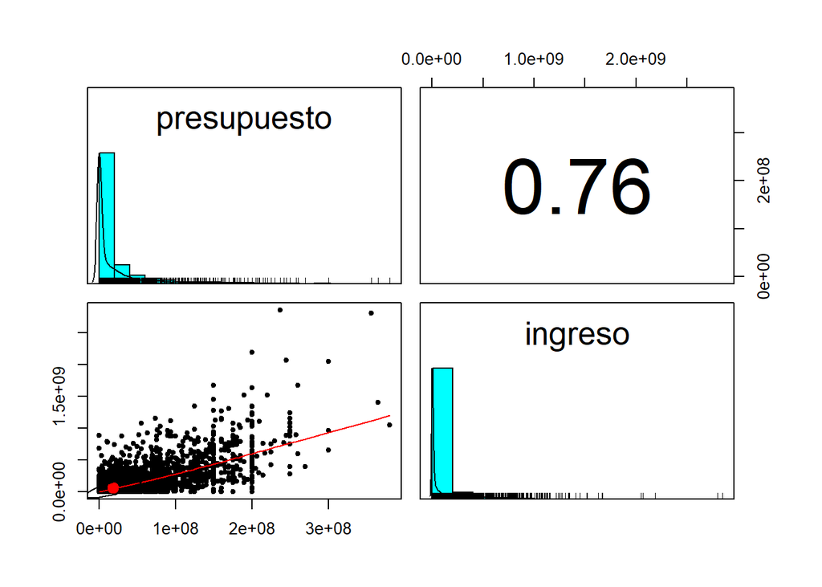

```r
presupuesto<-datos$budget
ingreso <- datos$revenue
presupuestoVsIngreso <- data.frame(presupuesto,ingreso)
library(psych)
pairs.panels(presupuestoVsIngreso)
```

#### 4.12 ¿Se asocian ciertos meses de lanzamiento con mejores ingresos?

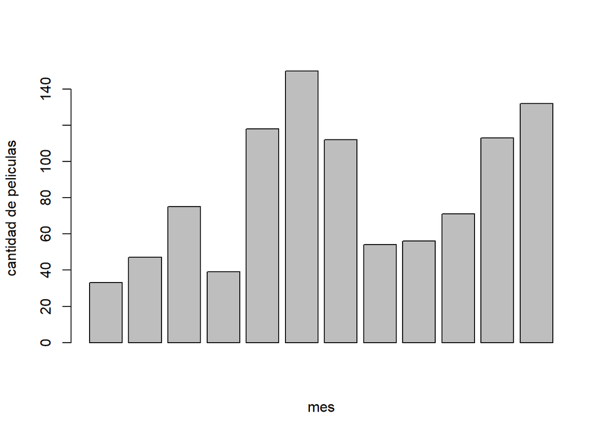

```r
fecha<-datos$releaseDate
mes <- 0
for (i in 1:length(fecha)){
  contador <- 0
  esteMes <- ""
  for (j in 1:nchar(fecha[i])){
    caracter <-substr(fecha[i],j,j)
    if (caracter=="-"){
      contador<-contador+1
    }else{
      if(contador==1){
        esteMes<- paste(esteMes,caracter)
      }
    }
  }
  mes[i]<-switch(esteMes,
                 " 0 1"=1,
                 " 0 2"=2,
                 " 0 3"=3,
                 " 0 4"=4,
                 " 0 5"=5,
                 " 0 6"=6,
                 " 0 7"=7,
                 " 0 8"=8,
                 " 0 9"=9,
                 " 1 0"=10,
                 " 1 1"=11,
                 " 1 2"=12,
                 )
}
ordenIngreso<- order(ingreso,decreasing = TRUE)
mejoresMeses <- 0
for(i in 1:12){
  mejoresMeses[i]<- 0
}
for (i in 1:(length(ordenIngreso)*0.1)){
  elMejorMes <- mes[ordenIngreso[i]]
  mejoresMeses[elMejorMes]<- mejoresMeses[elMejorMes]+1
}
barplot(mejoresMeses,
     xlab = "mes", ylab = "cantidad de peliculas")
```

```r
for (i in 1:12){
  mejoresMeses[i]<- mejoresMeses[i]/(length(ordenIngreso)*0.1)
}
OrdenMeses<-order(mejoresMeses,decreasing = TRUE)
meses<-c("enero","febrero","marzo","abril","mayo","junio","julio","agosto","septiembre","octubre","noviembre","diciembre")
```

del 10% de las peliculas con mejores ingresos, el 15% fue estrenada en junio, en cambio solo el 3.3% fue estrenada en enero, por lo cual si podriamos asociar algunos meses de lanzamiento con mejores ingresos

#### 4.13 ¿En qué meses se han visto los lanzamientos con mejores ingresos?¿cuantas películas, en promedio, se han lanzado por mes?

```r
peliculasPorMes<-0
for (i in 1:12){
  peliculasPorMes[i]<-0
}
for (i in 1:(length(ordenIngreso))){
  peliculasPorMes[mes[i]]<- peliculasPorMes[mes[i]]+1
}
```

los 2 mejores ingresos en un lanzamiento se han visto en los meses de diciembre y abril. Ademas se lanzan en promedio 833.3333333 peliculas al mes

#### 4.14 ¿Cómo se correlacionan las calificaciones con el éxito comercial?

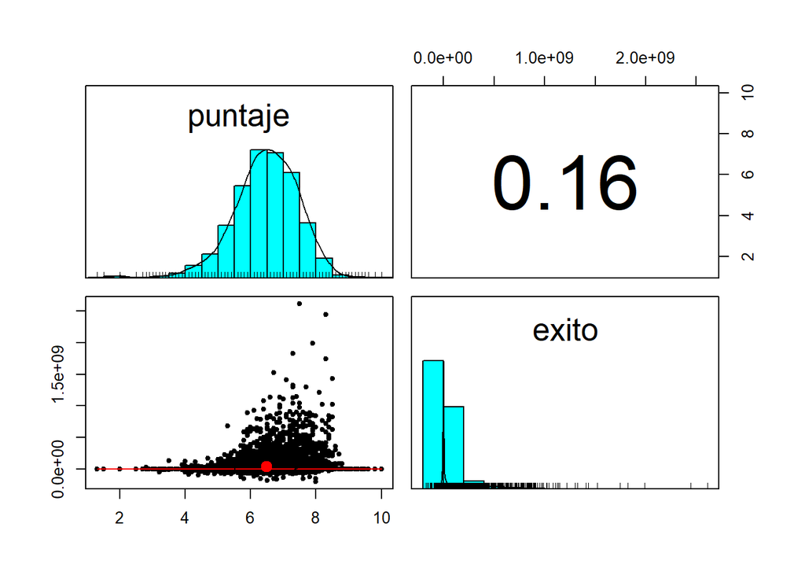

```r
exito<-ingreso-presupuesto
exitoVsPuntaje <- data.frame(puntaje,exito)
library(psych)
pairs.panels(exitoVsPuntaje)
```

como podemos ver, la corelacion entre los datos es muy baja, aunque lo que si es que las peliculas mas exitosas tuvieron buena puntuacion y las que tuvieron peor puntuacion fueron de las peores evaluadas

#### 4.15 ¿A qué género principal pertenecen las películas más largas?

```r
genero<-datos$genres
for(i in 1:length(genero)){
  generoActual<-""
  verificador<-0
  for (j in 1:nchar(genero[i])){
    caracter <-substr(genero[i],j,j)
    if(caracter=="|"){
      verificador<-1
    }
    if(verificador==0){
      generoActual<-paste(generoActual,caracter)
    }
  }
  genero[i]<-generoActual
}
largo<-datos$runtime
ordenLargo<-order(largo,decreasing = TRUE)
generos <- genero[ordenLargo[1]]
MejoresGeneros <-1
laMasLarga<-genero[ordenLargo[1]]
contador<-1
verificador2<-0
for (i in 2:(length(ordenLargo)*0.1)){
  if(verificador2==0){
    if(genero[ordenLargo[i]]==laMasLarga){
      contador<-contador+1
    }else{
      verificador2<-1
    }
  }
  nuevoGenero<-genero[ordenLargo[i]]
  verificador<-0
  numero<-0
  for(j in 1:length(generos)){
    if(generos[j]==nuevoGenero){
      verificador<-1
      numero<-j
    }
  }
  if(verificador==1){
    MejoresGeneros[numero]=MejoresGeneros[numero]+1
  }else{
    MejoresGeneros[length(generos)+1]<- 1
    generos[length(generos)+1]<-nuevoGenero
  }
}
ordenMasLargas<-order(MejoresGeneros,decreasing = TRUE)
for (i in 2:(length(MejoresGeneros))){
  MejoresGeneros[i]<-MejoresGeneros[i]/(length(ordenLargo)*0.1)
}
```

del 10% de las peliculas mas largas, el 34.7% son de genero principal D r a m a y el 19.2% son A c t i o n aunque las 2 peliculas mas largas son de genero D o c u m e n t a r y